# Neural Representations of Multilayer Social Network Information Analysis: Univariate

# 1 Model 1 (Relative Dual Status)

Run regression model for relative dual status.

```r
# options(mc.cores = parallel::detectCores())
# m <- brm(neural_response ~ dual_relative_status_cw +
#                   pid_mean_attractive_rating_cw + face_mean_attractive_rating_cw +
#                   pid_gender_cw + face_gender_cw +
#                   pid_college_year_cw + face_college_year_cw +
#                   pid_educ_parents_cw + face_educ_parents_cw +
#                   pid_income_num_cw + face_income_num_cw +
#                   (1 | groupID:pid) + (1 | groupID:face) +
#                   (dual_relative_status_cw | brain_system:roi),
#             data = d,
#             control = list(adapt_delta = 0.99),
#             seed = 123)
# save(m, file = sprintf("%s/Model Results/Univariate_Model1_Controls.RData", path))
```

Obtain ROI-level varying betas for the main effect of targets’ **relative dual status measures** on the perceivers’ ROI-level neural responses.

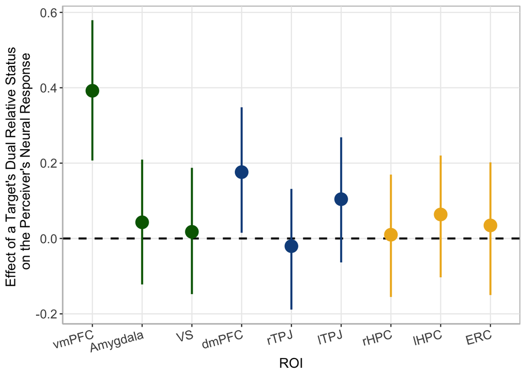

```r
# Load model results
load(sprintf("%s/Model Results/Univariate_Model1_Controls.RData", path))

# Extract posterior draws
roi_draws <- m %>%
  spread_draws(b_Intercept, b_dual_relative_status_cw,
               `r_brain_system:roi`[roi, term]) %>%
  filter(term == "dual_relative_status_cw")  %>%
  mutate(beta =  b_dual_relative_status_cw + `r_brain_system:roi`) %>%
  mutate(roi = dplyr::recode(roi,
                             "social_cognition_Saxe_dmPFC" = "dmPFC",
                             "valuation_HO_amygdala" = "Amygdala",
                             "relational_binding_r_HPC" = "rHPC",
                             "social_cognition_r_TPJ" = "rTPJ",
                             "valuation_Kable_VS" = "VS",
                             "relational_binding_ERC" = "ERC",
                             "relational_binding_l_HPC" = "lHPC",
                             "social_cognition_l_TPJ" = "lTPJ",
                             "valuation_vmPFC" = "vmPFC"),
         roi = factor(roi, levels = c("vmPFC", "Amygdala", "VS",
                                          "dmPFC", "rTPJ", "lTPJ",
                                          "rHPC", "lHPC", "ERC")),
         roi_type = ifelse(roi %in% c("vmPFC", "Amygdala", "VS"), "valuation",
                        ifelse(roi %in% c("dmPFC", "rTPJ", "lTPJ"), "social_cognition",
                               "relational_binding"))) %>%
  select(.draw, roi, roi_type, term, beta)

# Summarize estimates per ROI
b_df <- roi_draws %>%
  group_by(roi, roi_type, term) %>%
  summarise(beta_2d = median(beta),
            sd = sd(beta),
            low_ci = quantile(beta, 0.025),
            upp_ci = quantile(beta, 0.975))

# Plot betas' posterior mean and 95% credible interval
ggplot(data = b_df[b_df$term == "dual_relative_status_cw",],
       aes(x = roi,
           y = beta_2d)) +
  geom_hline(yintercept = 0,
             linewidth = 0.9, linetype = 2) +
  geom_pointrange(aes(ymin = low_ci,
                      ymax = upp_ci, color = roi_type),
                   size = 1.2, linewidth = .9) +
                   # size = 2, linewidth = 2.5) +
  scale_color_manual(values = c("goldenrod2", "dodgerblue4", "darkgreen")) +
  labs(x = "ROI", y = "Effect of a Target's Dual Relative Status
  on the Perceiver's Neural Response")
```

Check results.

```r
# Arrange data
b_df_table <- b_df %>%
  filter(term == "dual_relative_status_cw") %>%
  ungroup() %>%
  mutate(across(where(is.numeric), ~ round(.x, 2)),
         CI_95 = paste0("[", round(low_ci, 2), ", ", round(upp_ci, 2), "]")) %>%
  select(-any_of(c("low_ci", "upp_ci", "roi_type", "term"))) %>%
  arrange(roi)

# Create table of results
b_df_table <- flextable(b_df_table) %>%
  set_header_labels(roi = "ROI",
    beta_2d = "Beta Estimate",
    sd = "SE",
    CI_95 = "95% CI") %>%
  autofit() %>%
  theme_booktabs()

# Save to Word document
doc <- read_docx() %>%
  body_add_par("Table: Univariate Results: Effect of Target's Relative Dual Status on ROI Neural Activity",
               style = "heading 2") %>%
  body_add_flextable(b_df_table)

print(doc, target = sprintf("%s/Tables/TableS16_Univariate_Model1_Dual_Status_Betas_Controls.docx", path))

b_df_table
```

| ROI | Beta Estimate | SE | 95% CI |
| --- | --- | --- | --- |
| vmPFC | 0.39 | 0.09 | [0.21, 0.58] |
| Amygdala | 0.04 | 0.08 | [-0.12, 0.21] |
| VS | 0.02 | 0.09 | [-0.15, 0.19] |
| dmPFC | 0.18 | 0.08 | [0.02, 0.35] |
| rTPJ | -0.02 | 0.08 | [-0.19, 0.13] |
| lTPJ | 0.10 | 0.08 | [-0.06, 0.27] |
| rHPC | 0.01 | 0.08 | [-0.16, 0.17] |
| lHPC | 0.06 | 0.08 | [-0.1, 0.22] |
| ERC | 0.03 | 0.09 | [-0.15, 0.2] |

What percentage of the distribution is higher than zero for the vmPFC and dmPFC main effects?

```r
# vmPFC
round(length(which(roi_draws$beta[roi_draws$roi == "vmPFC"]>0))/4000*100,1)
```

```
## [1] 100
```

```r
# dmPFC
round(length(which(roi_draws$beta[roi_draws$roi == "dmPFC"]>0))/4000*100,1)
```

```
## [1] 98.4
```

Check convergence (R-hat, bulk & tail ESS).

```r
summary(m)
```

```
##  Family: gaussian
##   Links: mu = identity
## Formula: neural_response ~ dual_relative_status_cw + pid_mean_attractive_rating_cw + face_mean_attractive_rating_cw + pid_gender_cw + face_gender_cw + pid_college_year_cw + face_college_year_cw + pid_educ_parents_cw + face_educ_parents_cw + pid_income_num_cw + face_income_num_cw + (1 | groupID:pi…
##    Data: d (Number of observations: 19568)
##   Draws: 4 chains, each with iter = 2000; warmup = 1000; thin = 1;
##          total post-warmup draws = 4000
##
## Multilevel Hyperparameters:
## ~brain_system:roi (Number of levels: 9)
##                                        Estimate Est.Error l-95% CI u-95% CI
## sd(Intercept)                              0.85      0.28     0.48     1.61
## sd(dual_relative_status_cw)                0.18      0.07     0.08     0.35
## cor(Intercept,dual_relative_status_cw)     0.32      0.33    -0.41     0.84
##                                        Rhat Bulk_ESS Tail_ESS
## sd(Intercept)                          1.00     1041     1677
## sd(dual_relative_status_cw)            1.00     1802     2142
## cor(Intercept,dual_relative_status_cw) 1.00     2228     2702
##
## ~groupID:face (Number of levels: 231)
##               Estimate Est.Error l-95% CI u-95% CI Rhat Bulk_ESS Tail_ESS
## sd(Intercept)     0.78      0.05     0.68     0.90 1.00     1142     2665
##
## ~groupID:pid (Number of levels: 93)
##               Estimate Est.Error l-95% CI u-95% CI Rhat Bulk_ESS Tail_ESS
## sd(Intercept)     0.69      0.06     0.58     0.82 1.00     1101     2081
##
## Regression Coefficients:
##                                Estimate Est.Error l-95% CI u-95% CI Rhat
## Intercept                          0.71      0.32     0.06     1.32 1.00
## dual_relative_status_cw            0.09      0.08    -0.07     0.25 1.00
## pid_mean_attractive_rating_cw     -0.08      0.10    -0.27     0.11 1.00
## face_mean_attractive_rating_cw     0.07      0.07    -0.07     0.20 1.00
## pid_gender_cw                      0.06      0.10    -0.11     0.26 1.00
## face_gender_cw                    -0.11      0.07    -0.25     0.03 1.00
## pid_college_year_cw               -0.09      0.09    -0.26     0.08 1.01
## face_college_year_cw               0.04      0.06    -0.08     0.16 1.00
## pid_educ_parents_cw               -0.06      0.11    -0.29     0.17 1.00
## face_educ_parents_cw               0.11      0.08    -0.04     0.26 1.00
## pid_income_num_cw                  0.02      0.11    -0.20     0.23 1.01
## face_income_num_cw                -0.01      0.08    -0.16     0.14 1.00
##                                Bulk_ESS Tail_ESS
## Intercept                           593     1088
## dual_relative_status_cw            1634     2037
## pid_mean_attractive_rating_cw       990     1799
## face_mean_attractive_rating_cw     1123     1836
## pid_gender_cw                      1009     1764
## face_gender_cw                     1253     1936
## pid_college_year_cw                 868     1724
## face_college_year_cw               1224     2056
## pid_educ_parents_cw                 890     1856
## face_educ_parents_cw               1061     2176
## pid_income_num_cw                   745     1485
## face_income_num_cw                 1095     1778
##
## Further Distributional Parameters:
##       Estimate Est.Error l-95% CI u-95% CI Rhat Bulk_ESS Tail_ESS
## sigma     3.46      0.02     3.43     3.50 1.00    11223     2988
##
## Draws were sampled using sampling(NUTS). For each parameter, Bulk_ESS
## and Tail_ESS are effective sample size measures, and Rhat is the potential
## scale reduction factor on split chains (at convergence, Rhat = 1).
```

```r
draws <- as_draws_df(m)
summarise_draws(draws, rhat, "ess_bulk", "ess_tail") %>%
  filter(grepl("brain_system:roi", variable)) %>%
  mutate(across(where(is.numeric), ~ round(.x, 4)))
```

| variable | rhat | ess_bulk | ess_tail |
| --- | --- | --- | --- |
| sd_brain_system:roi__Intercept | 1.0030 | 1041.0524 | 1676.852 |
| sd_brain_system:roi__dual_relative_status_cw | 1.0001 | 1802.0910 | 2141.683 |
| cor_brain_system:roi__Intercept__dual_relative_status_cw | 1.0021 | 2227.8626 | 2702.245 |
| r_brain_system:roi[relational_binding_ERC,Intercept] | 1.0039 | 622.1299 | 1362.065 |
| r_brain_system:roi[relational_binding_l_HPC,Intercept] | 1.0032 | 622.6759 | 1315.164 |
| r_brain_system:roi[relational_binding_r_HPC,Intercept] | 1.0040 | 593.4680 | 1149.218 |
| r_brain_system:roi[social_cognition_l_TPJ,Intercept] | 1.0039 | 627.9211 | 1245.428 |
| r_brain_system:roi[social_cognition_r_TPJ,Intercept] | 1.0042 | 599.2835 | 1273.251 |
| r_brain_system:roi[social_cognition_Saxe_dmPFC,Intercept] | 1.0040 | 623.0115 | 1336.575 |
| r_brain_system:roi[valuation_HO_amygdala,Intercept] | 1.0036 | 639.0550 | 1258.362 |

[output cut: 11 more lines]

# 2 Model 2 (Relative Popularity Status)

Run regression model for relative popularity status alone.

```r
# options(mc.cores = parallel::detectCores())
# m2 <- brm(neural_response ~ face_like_strength_in_cw + pid_like_strength_in_cw +
#                    pid_mean_attractive_rating_cw + face_mean_attractive_rating_cw +
#                    pid_gender_cw + face_gender_cw +
#                    pid_college_year_cw + face_college_year_cw +
#                    pid_educ_parents_cw + face_educ_parents_cw +
#                    pid_income_num_cw + face_income_num_cw +
#                    (1 | groupID:pid) + (1 | groupID:face) +
#                    (face_like_strength_in_cw | brain_system:roi),
#             data = d,
#             control = list(adapt_delta = 0.99),
#             seed = 123)
# save(m2, file = sprintf("%s/Model Results/Univariate_Model2_Controls.RData", path))
```

Obtain ROI-level varying betas for the main effect of a **target’s popularity status measure** on the perceiver’s ROI-level neural responses. Since we are controlling in the model for the perceiver’s popularity status, this is in effect a measure of the target’s **relative** popularity status.

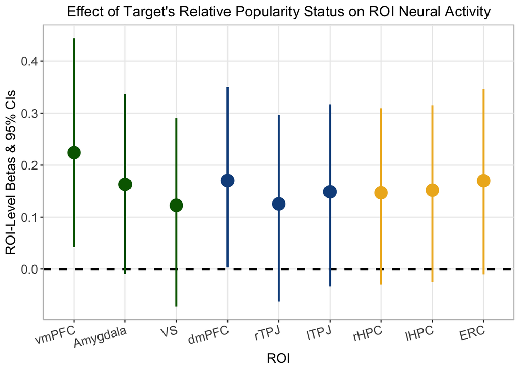

```r
# Load model results
load(sprintf("%s/Model Results/Univariate_Model2_Controls.RData", path))

# Extract posterior draws
roi_draws <- m2 %>%
  spread_draws(b_face_like_strength_in_cw,
               `r_brain_system:roi`[roi, term]) %>%
  filter(term == "face_like_strength_in_cw") %>%
  mutate(beta = b_face_like_strength_in_cw + `r_brain_system:roi`) %>%
  mutate(roi = dplyr::recode(roi,
                             "social_cognition_Saxe_dmPFC" = "dmPFC",
                             "valuation_HO_amygdala" = "Amygdala",
                             "relational_binding_r_HPC" = "rHPC",
                             "social_cognition_r_TPJ" = "rTPJ",
                             "valuation_Kable_VS" = "VS",
                             "relational_binding_ERC" = "ERC",
                             "relational_binding_l_HPC" = "lHPC",
                             "social_cognition_l_TPJ" = "lTPJ",
                             "valuation_vmPFC" = "vmPFC"),
         roi = factor(roi, levels = c("vmPFC", "Amygdala", "VS",
                                          "dmPFC", "rTPJ", "lTPJ",
                                          "rHPC", "lHPC", "ERC")),
         roi_type = ifelse(roi %in% c("vmPFC", "Amygdala", "VS"), "valuation",
                        ifelse(roi %in% c("dmPFC", "rTPJ", "lTPJ"), "social_cognition",
                               "relational_binding"))) %>%
  select(.draw, roi, roi_type, beta)

# Summarize estimates per ROI
b_df_like <- roi_draws %>%
  group_by(roi, roi_type, term) %>%
  summarise(beta_like = median(beta),
            sd = sd(beta),
            low_ci = quantile(beta, 0.025),
            upp_ci = quantile(beta, 0.975))

# Plot betas' posterior means and 95% credible intervals
ggplot(data = b_df_like,
       aes(x = roi,
           y = beta_like)) +
  geom_hline(yintercept = 0,
             linewidth = 0.9, linetype = 2) +
  geom_pointrange(aes(ymin = low_ci,
                      ymax = upp_ci, color = roi_type),
                  size = 1.2, linewidth = .9) +
  scale_color_manual(values = c("goldenrod2", "dodgerblue4", "darkgreen")) +
  labs(x = "ROI", y = "ROI-Level Betas & 95% CIs",
       title = "Effect of Target's Relative Popularity Status on ROI Neural Activity")
```

Check results.

```r
# Arrange data
b_df_table <- b_df_like %>%
  ungroup() %>%
  mutate(across(where(is.numeric), ~ round(.x, 2)),
         CI_95 = paste0("[", round(low_ci, 2), ", ", round(upp_ci, 2), "]")) %>%
  select(-any_of(c("low_ci", "upp_ci", "roi_type", "term"))) %>%
  arrange(roi)

# Create table of results
b_df_table <- flextable(b_df_table) %>%
  set_header_labels(roi = "ROI",
    beta_like = "Beta Estimate",
    sd = "SE",
    CI_95 = "95% CI") %>%
  autofit() %>%
  theme_booktabs()

# Save to Word document
doc <- read_docx() %>%
  body_add_par("Table: Univariate Results: Effect of Target's Relative Popularity Status on ROI Neural Activity",
               style = "heading 2") %>%
  body_add_flextable(b_df_table)

print(doc, target = sprintf("%s/Tables/TableS14_Univariate_Model2_Popularity_Betas_Controls.docx", path))

b_df_table
```

| ROI | Beta Estimate | SE | 95% CI |
| --- | --- | --- | --- |
| vmPFC | 0.22 | 0.10 | [0.04, 0.44] |
| Amygdala | 0.16 | 0.09 | [-0.01, 0.34] |
| VS | 0.12 | 0.09 | [-0.07, 0.29] |
| dmPFC | 0.17 | 0.09 | [0, 0.35] |
| rTPJ | 0.13 | 0.09 | [-0.06, 0.3] |
| lTPJ | 0.15 | 0.09 | [-0.03, 0.32] |
| rHPC | 0.15 | 0.09 | [-0.03, 0.31] |
| lHPC | 0.15 | 0.09 | [-0.02, 0.32] |
| ERC | 0.17 | 0.09 | [-0.01, 0.35] |

What percentage of the distribution is higher than zero for different ROI main effects?

```r
# vmPFC
round(length(which(roi_draws$beta[roi_draws$roi == "vmPFC"]>0))/4000*100,1)
```

```
## [1] 99.3
```

```r
# dmPFC
round(length(which(roi_draws$beta[roi_draws$roi == "dmPFC"]>0))/4000*100,1)
```

```
## [1] 97.6
```

Check convergence (R-hat, bulk & tail ESS).

```r
summary(m2)
```

```
##  Family: gaussian
##   Links: mu = identity
## Formula: neural_response ~ face_like_strength_in_cw + pid_like_strength_in_cw + pid_mean_attractive_rating_cw + face_mean_attractive_rating_cw + pid_gender_cw + face_gender_cw + pid_college_year_cw + face_college_year_cw + pid_educ_parents_cw + face_educ_parents_cw + pid_income_num_cw + face_inco…
##    Data: d (Number of observations: 19568)
##   Draws: 4 chains, each with iter = 2000; warmup = 1000; thin = 1;
##          total post-warmup draws = 4000
##
## Multilevel Hyperparameters:
## ~brain_system:roi (Number of levels: 9)
##                                         Estimate Est.Error l-95% CI u-95% CI
## sd(Intercept)                               0.83      0.26     0.48     1.48
## sd(face_like_strength_in_cw)                0.07      0.05     0.00     0.18
## cor(Intercept,face_like_strength_in_cw)     0.32      0.49    -0.82     0.97
##                                         Rhat Bulk_ESS Tail_ESS
## sd(Intercept)                           1.00     1027     2166
## sd(face_like_strength_in_cw)            1.00     1810     1746
## cor(Intercept,face_like_strength_in_cw) 1.00     4651     2590
##
## ~groupID:face (Number of levels: 231)
##               Estimate Est.Error l-95% CI u-95% CI Rhat Bulk_ESS Tail_ESS
## sd(Intercept)     0.79      0.05     0.69     0.90 1.00     1275     2437
##
## ~groupID:pid (Number of levels: 93)
##               Estimate Est.Error l-95% CI u-95% CI Rhat Bulk_ESS Tail_ESS
## sd(Intercept)     0.69      0.06     0.58     0.82 1.01     1149     1822
##
## Regression Coefficients:
##                                Estimate Est.Error l-95% CI u-95% CI Rhat
## Intercept                          0.70      0.30     0.09     1.29 1.00
## face_like_strength_in_cw           0.16      0.08     0.00     0.31 1.00
## pid_like_strength_in_cw            0.06      0.12    -0.18     0.31 1.00
## pid_mean_attractive_rating_cw     -0.07      0.10    -0.26     0.12 1.00
## face_mean_attractive_rating_cw     0.06      0.07    -0.08     0.20 1.00
## pid_gender_cw                      0.07      0.09    -0.11     0.25 1.00
## face_gender_cw                    -0.11      0.07    -0.25     0.03 1.00
## pid_college_year_cw               -0.10      0.09    -0.26     0.07 1.00
## face_college_year_cw               0.06      0.06    -0.07     0.18 1.00
## pid_educ_parents_cw               -0.05      0.12    -0.29     0.18 1.00
## face_educ_parents_cw               0.09      0.08    -0.05     0.25 1.00
## pid_income_num_cw                  0.00      0.11    -0.21     0.21 1.00
```

[output cut: 8 more lines]

```
## face_gender_cw                     1294     1893
## pid_college_year_cw                1110     1823
## face_college_year_cw               1105     1945
## pid_educ_parents_cw                1018     1662
## face_educ_parents_cw               1246     2384
## pid_income_num_cw                  1158     2103
## face_income_num_cw                 1440     1982
##
## Further Distributional Parameters:
##       Estimate Est.Error l-95% CI u-95% CI Rhat Bulk_ESS Tail_ESS
## sigma     3.47      0.02     3.43     3.50 1.00     8707     2609
##
## Draws were sampled using sampling(NUTS). For each parameter, Bulk_ESS
## and Tail_ESS are effective sample size measures, and Rhat is the potential
## scale reduction factor on split chains (at convergence, Rhat = 1).
```

```r
draws <- as_draws_df(m2)
summarise_draws(draws, rhat, "ess_bulk", "ess_tail") %>%
  filter(grepl("brain_system:roi", variable)) %>%
  mutate(across(where(is.numeric), ~ round(.x, 4)))
```

| variable | rhat | ess_bulk | ess_tail |
| --- | --- | --- | --- |
| sd_brain_system:roi__Intercept | 1.0028 | 1027.3112 | 2165.957 |
| sd_brain_system:roi__face_like_strength_in_cw | 1.0018 | 1810.2437 | 1746.020 |
| cor_brain_system:roi__Intercept__face_like_strength_in_cw | 1.0003 | 4650.7588 | 2590.476 |
| r_brain_system:roi[relational_binding_ERC,Intercept] | 1.0001 | 959.7677 | 1813.175 |
| r_brain_system:roi[relational_binding_l_HPC,Intercept] | 1.0017 | 972.4820 | 1740.830 |
| r_brain_system:roi[relational_binding_r_HPC,Intercept] | 1.0017 | 944.9640 | 1593.518 |
| r_brain_system:roi[social_cognition_l_TPJ,Intercept] | 1.0007 | 943.1230 | 1719.782 |
| r_brain_system:roi[social_cognition_r_TPJ,Intercept] | 1.0012 | 974.8519 | 1734.807 |
| r_brain_system:roi[social_cognition_Saxe_dmPFC,Intercept] | 1.0011 | 943.6230 | 1748.265 |
| r_brain_system:roi[valuation_HO_amygdala,Intercept] | 1.0007 | 965.9936 | 1698.421 |

[output cut: 11 more lines]

# 3 Model 3 (Relative Leadership Status)

Run regression model for relative leadership status alone.

```r
# options(mc.cores = parallel::detectCores())
# m3 <- brm(neural_response ~ face_leader_strength_in_cw + pid_leader_strength_in_cw +
#                    pid_mean_attractive_rating_cw + face_mean_attractive_rating_cw +
#                    pid_gender_cw + face_gender_cw +
#                    pid_college_year_cw + face_college_year_cw +
#                    pid_educ_parents_cw + face_educ_parents_cw +
#                    pid_income_num_cw + face_income_num_cw +
#                    (1 | groupID:pid) + (1 | groupID:face) +
#                    (face_leader_strength_in_cw | brain_system:roi),
#             data = d,
#             control = list(adapt_delta = 0.99),
#             seed = 123)
# save(m3, file = sprintf("%s/Model Results/Univariate_Model3_Controls.RData", path))
```

Obtain ROI-level varying betas for the main effect of a **target’s leadership status measure** on the perceiver’s ROI-level neural responses. Since we are controlling in the model for the perceiver’s leadership status, this is in effect a measure of the target’s **relative** leadership status.

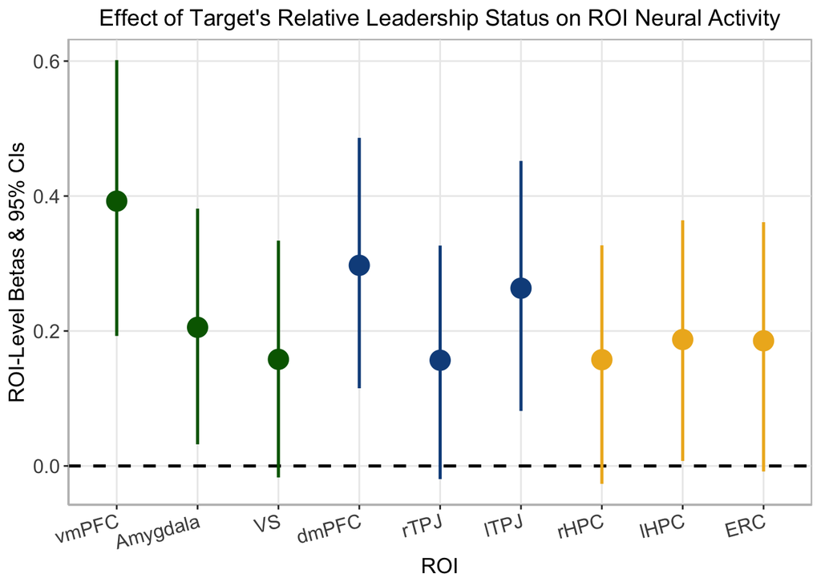

```r
# Load model results
load(sprintf("%s/Model Results/Univariate_Model3_Controls.RData", path))

# Extract posterior draws
roi_draws <- m3 %>%
  spread_draws(b_face_leader_strength_in_cw,
               `r_brain_system:roi`[roi, term]) %>%
  filter(term == "face_leader_strength_in_cw") %>%
  mutate(beta = b_face_leader_strength_in_cw + `r_brain_system:roi`) %>%
  mutate(roi = dplyr::recode(roi,
                             "social_cognition_Saxe_dmPFC" = "dmPFC",
                             "valuation_HO_amygdala" = "Amygdala",
                             "relational_binding_r_HPC" = "rHPC",
                             "social_cognition_r_TPJ" = "rTPJ",
                             "valuation_Kable_VS" = "VS",
                             "relational_binding_ERC" = "ERC",
                             "relational_binding_l_HPC" = "lHPC",
                             "social_cognition_l_TPJ" = "lTPJ",
                             "valuation_vmPFC" = "vmPFC"),
         roi = factor(roi, levels = c("vmPFC", "Amygdala", "VS",
                                          "dmPFC", "rTPJ", "lTPJ",
                                          "rHPC", "lHPC", "ERC")),
         roi_type = ifelse(roi %in% c("vmPFC", "Amygdala", "VS"), "valuation",
                        ifelse(roi %in% c("dmPFC", "rTPJ", "lTPJ"), "social_cognition",
                               "relational_binding"))) %>%
  select(.draw, roi, roi_type, beta)

# Summarize estimates per ROI
b_df_leader <- roi_draws %>%
  group_by(roi, roi_type, term) %>%
  summarise(beta_leader = median(beta),
            sd = sd(beta),
            low_ci = quantile(beta, 0.025),
            upp_ci = quantile(beta, 0.975))

# Plot betas' posterior means and 95% credible intervals
ggplot(data = b_df_leader,
       aes(x = roi,
           y = beta_leader)) +
  geom_hline(yintercept = 0,
             linewidth = 0.9, linetype = 2) +
  geom_pointrange(aes(ymin = low_ci,
                      ymax = upp_ci, color = roi_type),
                  size = 1.2, linewidth = .9) +
  scale_color_manual(values = c("goldenrod2", "dodgerblue4", "darkgreen")) +
  labs(x = "ROI", y = "ROI-Level Betas & 95% CIs",
       title = "Effect of Target's Relative Leadership Status on ROI Neural Activity")
```

Check results.

```r
# Arrange data
b_df_table <- b_df_leader %>%
  ungroup() %>%
  mutate(across(where(is.numeric), ~ round(.x, 2)),
         CI_95 = paste0("[", round(low_ci, 2), ", ", round(upp_ci, 2), "]")) %>%
  select(-any_of(c("low_ci", "upp_ci", "roi_type", "term"))) %>%
  arrange(roi)

# Create table of results
b_df_table <- flextable(b_df_table) %>%
  set_header_labels(roi = "ROI",
    beta_leader = "Beta Estimate",
    sd = "SE",
    CI_95 = "95% CI") %>%
  autofit() %>%
  theme_booktabs()

# Save to Word document
doc <- read_docx() %>%
  body_add_par("Table: Univariate Results: Effect of Target's Relative Leadership Status on ROI Neural Activity",
               style = "heading 2") %>%
  body_add_flextable(b_df_table)

print(doc, target = sprintf("%s/Tables/TableS15_Univariate_Model3_Leadership_Betas_Controls.docx", path))

b_df_table
```

| ROI | Beta Estimate | SE | 95% CI |
| --- | --- | --- | --- |
| vmPFC | 0.39 | 0.11 | [0.19, 0.6] |
| Amygdala | 0.21 | 0.09 | [0.03, 0.38] |
| VS | 0.16 | 0.09 | [-0.02, 0.33] |
| dmPFC | 0.30 | 0.09 | [0.12, 0.49] |
| rTPJ | 0.16 | 0.09 | [-0.02, 0.33] |
| lTPJ | 0.26 | 0.09 | [0.08, 0.45] |
| rHPC | 0.16 | 0.09 | [-0.03, 0.33] |
| lHPC | 0.19 | 0.09 | [0.01, 0.36] |
| ERC | 0.19 | 0.09 | [-0.01, 0.36] |

What percentage of the distribution is higher than zero for different ROI main effects?

```r
# vmPFC
round(length(which(roi_draws$beta[roi_draws$roi == "vmPFC"]>0))/4000*100,1)
```

```
## [1] 100
```

```r
# bilateral amygdala
round(length(which(roi_draws$beta[roi_draws$roi == "Amygdala"]>0))/4000*100,1)
```

```
## [1] 99
```

```r
# dmPFC
round(length(which(roi_draws$beta[roi_draws$roi == "dmPFC"]>0))/4000*100,1)
```

```
## [1] 100
```

```r
# lTPJ
round(length(which(roi_draws$beta[roi_draws$roi == "lTPJ"]>0))/4000*100,1)
```

```
## [1] 99.8
```

```r
# lHPC
round(length(which(roi_draws$beta[roi_draws$roi == "lHPC"]>0))/4000*100,1)
```

```
## [1] 97.9
```

Check convergence (R-hat, bulk & tail ESS).

```r
summary(m2)
```

```
##  Family: gaussian
##   Links: mu = identity
## Formula: neural_response ~ face_like_strength_in_cw + pid_like_strength_in_cw + pid_mean_attractive_rating_cw + face_mean_attractive_rating_cw + pid_gender_cw + face_gender_cw + pid_college_year_cw + face_college_year_cw + pid_educ_parents_cw + face_educ_parents_cw + pid_income_num_cw + face_inco…
##    Data: d (Number of observations: 19568)
##   Draws: 4 chains, each with iter = 2000; warmup = 1000; thin = 1;
##          total post-warmup draws = 4000
##
## Multilevel Hyperparameters:
## ~brain_system:roi (Number of levels: 9)
##                                         Estimate Est.Error l-95% CI u-95% CI
## sd(Intercept)                               0.83      0.26     0.48     1.48
## sd(face_like_strength_in_cw)                0.07      0.05     0.00     0.18
## cor(Intercept,face_like_strength_in_cw)     0.32      0.49    -0.82     0.97
##                                         Rhat Bulk_ESS Tail_ESS
## sd(Intercept)                           1.00     1027     2166
## sd(face_like_strength_in_cw)            1.00     1810     1746
## cor(Intercept,face_like_strength_in_cw) 1.00     4651     2590
##
## ~groupID:face (Number of levels: 231)
##               Estimate Est.Error l-95% CI u-95% CI Rhat Bulk_ESS Tail_ESS
## sd(Intercept)     0.79      0.05     0.69     0.90 1.00     1275     2437
##
## ~groupID:pid (Number of levels: 93)
##               Estimate Est.Error l-95% CI u-95% CI Rhat Bulk_ESS Tail_ESS
## sd(Intercept)     0.69      0.06     0.58     0.82 1.01     1149     1822
##
## Regression Coefficients:
##                                Estimate Est.Error l-95% CI u-95% CI Rhat
## Intercept                          0.70      0.30     0.09     1.29 1.00
## face_like_strength_in_cw           0.16      0.08     0.00     0.31 1.00
## pid_like_strength_in_cw            0.06      0.12    -0.18     0.31 1.00
## pid_mean_attractive_rating_cw     -0.07      0.10    -0.26     0.12 1.00
## face_mean_attractive_rating_cw     0.06      0.07    -0.08     0.20 1.00
## pid_gender_cw                      0.07      0.09    -0.11     0.25 1.00
## face_gender_cw                    -0.11      0.07    -0.25     0.03 1.00
## pid_college_year_cw               -0.10      0.09    -0.26     0.07 1.00
## face_college_year_cw               0.06      0.06    -0.07     0.18 1.00
## pid_educ_parents_cw               -0.05      0.12    -0.29     0.18 1.00
## face_educ_parents_cw               0.09      0.08    -0.05     0.25 1.00
## pid_income_num_cw                  0.00      0.11    -0.21     0.21 1.00
```

[output cut: 8 more lines]

```
## face_gender_cw                     1294     1893
## pid_college_year_cw                1110     1823
## face_college_year_cw               1105     1945
## pid_educ_parents_cw                1018     1662
## face_educ_parents_cw               1246     2384
## pid_income_num_cw                  1158     2103
## face_income_num_cw                 1440     1982
##
## Further Distributional Parameters:
##       Estimate Est.Error l-95% CI u-95% CI Rhat Bulk_ESS Tail_ESS
## sigma     3.47      0.02     3.43     3.50 1.00     8707     2609
##
## Draws were sampled using sampling(NUTS). For each parameter, Bulk_ESS
## and Tail_ESS are effective sample size measures, and Rhat is the potential
## scale reduction factor on split chains (at convergence, Rhat = 1).
```

```r
draws <- as_draws_df(m2)
summarise_draws(draws, rhat, "ess_bulk", "ess_tail") %>%
  filter(grepl("brain_system:roi", variable)) %>%
  mutate(across(where(is.numeric), ~ round(.x, 4)))
```

| variable | rhat | ess_bulk | ess_tail |
| --- | --- | --- | --- |
| sd_brain_system:roi__Intercept | 1.0028 | 1027.3112 | 2165.957 |
| sd_brain_system:roi__face_like_strength_in_cw | 1.0018 | 1810.2437 | 1746.020 |
| cor_brain_system:roi__Intercept__face_like_strength_in_cw | 1.0003 | 4650.7588 | 2590.476 |
| r_brain_system:roi[relational_binding_ERC,Intercept] | 1.0001 | 959.7677 | 1813.175 |
| r_brain_system:roi[relational_binding_l_HPC,Intercept] | 1.0017 | 972.4820 | 1740.830 |
| r_brain_system:roi[relational_binding_r_HPC,Intercept] | 1.0017 | 944.9640 | 1593.518 |
| r_brain_system:roi[social_cognition_l_TPJ,Intercept] | 1.0007 | 943.1230 | 1719.782 |
| r_brain_system:roi[social_cognition_r_TPJ,Intercept] | 1.0012 | 974.8519 | 1734.807 |
| r_brain_system:roi[social_cognition_Saxe_dmPFC,Intercept] | 1.0011 | 943.6230 | 1748.265 |
| r_brain_system:roi[valuation_HO_amygdala,Intercept] | 1.0007 | 965.9936 | 1698.421 |

[output cut: 11 more lines]

# 4 Plot of Model Results Together

Combine all slopes in one file so that we can visualize them together.

```r
b_df <- b_df %>%
  dplyr::rename(beta = beta_2d)
b_df$model <- "Relative Dual Status"
b_df_like <- b_df_like %>%
  dplyr::rename(beta = beta_like)
b_df_like$model <- "Relative Popularity Status"
b_df_leader<- b_df_leader%>%
  dplyr::rename(beta = beta_leader)
b_df_leader$model <- "Relative Leadership Status"
d2 <- rbind(b_df, b_df_like)
d3 <- rbind(d2, b_df_leader)
roi_order <- c("vmPFC", "Amygdala", "VS", "dmPFC",
               "rTPJ", "lTPJ", "rHPC", "lHPC", "ERC")
d3$roi <- factor(d3$roi, levels = rev(roi_order))
model_order <- c("Relative Popularity Status",
                 "Relative Leadership Status",
                 "Relative Dual Status")
d3$model <- factor(d3$model, levels = model_order)
```

Create a plot showing the effect of different types of target relative status (popularity, leadership, dual) on the perceiver’s neural responses in the 9 ROIs. This plot shows the ROI-level effects extracted from the 3 models together.

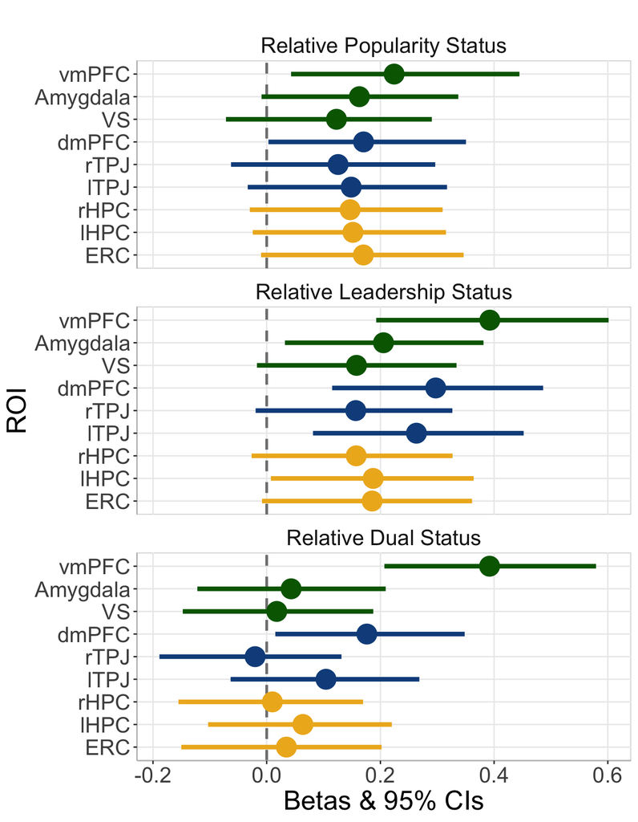

```r
ggplot(data = d3, aes(x = roi, y = beta)) +
  facet_wrap(~model, ncol = 1) +
  geom_hline(yintercept = 0, linewidth = 1,
             linetype = "dashed", color = "gray50") +
  geom_pointrange(aes(ymin = low_ci, ymax = upp_ci,
                      color = roi_type),
    size = 1.6, linewidth = 1.7) +
  scale_color_manual(values = c("goldenrod2",
                                "dodgerblue4", "darkgreen")) +
  labs(x = "ROI",
    y = "Betas & 95% CIs",
    title = "") +
  coord_flip() +
  theme_bw() +
  theme(
    axis.line = element_line(colour = "gray"),
    panel.border = element_blank(),
    panel.grid.minor = element_blank(),
    panel.background = element_rect(colour = "gray80", linewidth = .5),
    legend.position = "none",
    strip.background = element_blank(),
    axis.title = element_text(size = 21),
    axis.text  = element_text(size = 17),
    strip.text = element_text(size = 17))
```

```r
ggsave(file = sprintf("%s/Figures/Figure3.tiff", path),
       plot = last_plot(), width=10, height=10, units = "in", dpi = 600, compression = "lzw")
```